# Module 3: Project 1 by Team 5

mothur vs. QIIME2 Microbiome Data Analysis

Karl Abuan

May Ho

Jonah Lin

Leilynaz Malekafzali

Tiffany Yang

Abdur Rahman M. A. Basher

March 27, 2018

Abstract

# Introduction

We further address the planctomyces diversity correlation with oxygen and depth. We show that under the statistical framework there is little evidence to support our initial hypothesis. However, we claim that the linear model was not adequate to provide insightful knowledge regarding the existence of such correlations.

# Problem Formulation

# Materials and Experimental Configuration

## Experimental Protocols

To understand the correlation of microbial diversity and oxygen concentration across samples, we report four experimentally designed test protocols:

**P1.** Analysis of microbial community structure along with depth and oxygen concentration.

**P2.** Analysis of abundance information of Planctomyces along with depth and/or oxygen concentration.

**P3.** Estimate richness (number of OTUs/ASVs) for Planctomyces.

**P4.** Interpretation of abundance information of OTUs/ASVs of Planctomyces along with depth and/or oxygen concentration.

## Methods

### Shannon Diversity Index (SDI) and Chao1

We applied *Shannon diversity index (SDI)* to estimate the microbial diversity of Saanich Inlet dataset. It has the following definition:

$SDI = -\sum_i^R p_i \log(p_i)$

where $p_i$ represents the distribution of individuals belonging to the $i$th species, and $R$ represents the number of distinct species (Finotello, Mastrorilli, and Di Camillo 2016). It can be noted that SDI takes both the richness and abundance information to measure the expected uncertainty about species contained in a sample. The high SDI value suggests that species are evenly distributed while low SDI value implies species are disproportionality situated. SDI value could be zero meaning the sample contains exactly one or no species at all. However, SDI does not directly model the expected richness of a sample and, neither, it represents an accurate estimation of species diversity because the probability distribution of species is not knowable exactly; it is only an estimate from a sample.

In contrast to SDI, *Chao1* could be used to recover approximate true richness:

$Chao1=S_{obs}+\frac{\alpha}{2\beta}$

where $S_{obs}$ represents the observed richness, $\alpha$ and $\beta$ indicates the number of different species with exactly one or more than two counts, respectively. The Chao1 method is used to rectify the richness by including the distribution of the rarest species (Finotello, Mastrorilli, and Di Camillo 2016).

### General Linear Model

General linear model (LM) (Hastie, Tibshirani, and Friedman 2009) is employed to recover interactions between several factors that might be exhibited in Saanich Inlet dataset. In our experiments, we use a single regression model that relates a dependent variable $y$ (abundance) to a single quantitative independent variable $x_1$ (depth or oxygen), and it has the following form:

$y=\theta_0+\theta_1x_1+\epsilon$

The parameter $\theta_0$ is the $y$-intercept, which represents the expected value of $y$ when $x_1$ is zero. The parameter $\theta_1$ is the slope of the regression line, and it represents the expected change (positive or negative) in $y$ (abundance) for a unit increase in $x_1$ (depth or oxygen). $\theta_1$ could be $0$ indicating no effective change with $x_1$. And, $\epsilon$ is the error term and is usually set to $0$.

All the parameters could be estimated using ordinary least squares (OLS). However, to test the significance $\theta_1$, we formulate hypothesis testing: i)- the null hypothesis $H_0:\theta_1>\gamma$, which asserts that no additional predictive value over and above, contributed by $\theta_1$ and the $\gamma$ is an arbitrary cutoff probability from t-student distribution ; ii)- the alternative hypothesis $H_1: \theta_1\leq \gamma$ measures whether $x_j$ has additional predictive strengths.

If the weight of $\theta_1$, referred to as the level of significance (or $p$-value) and defines as a probability, is below or equal to $\gamma$ then we accept $H_1$; otherwise, accept $H_0$.

## Data Preporocessing

We used the Saanich Inlet dataset that was preprocessed using mothur and QIIME2. Afterward, samples were rarefied/normalized to $100,000$ sequences per sample to facilitate comparisons between samples. The rarefied counts were then converted to relative abundance percentages. Next, we perform a series of filterings according to three rules: i)- exclude OTUs that are not observed for more than $4$ samples; ii)- prune samples and OTUs with unknown values, such as `unclassified` value; and iii)- any phylum fail to have more than $5$ OTUs should be trimmed. This has resulted in 371 and 190 taxa from mothur and QIIME2, respectively. No other preprocessing were applied. The implementations are done entirely using R (v 3.4.3) and relied on some efficient third-party libraries, such as `phyloseq`, `tidyverse`, `gridExtra`, and `magrittr`.

# Results

## Analysis of microbial community structure along with depth and oxygen concentration

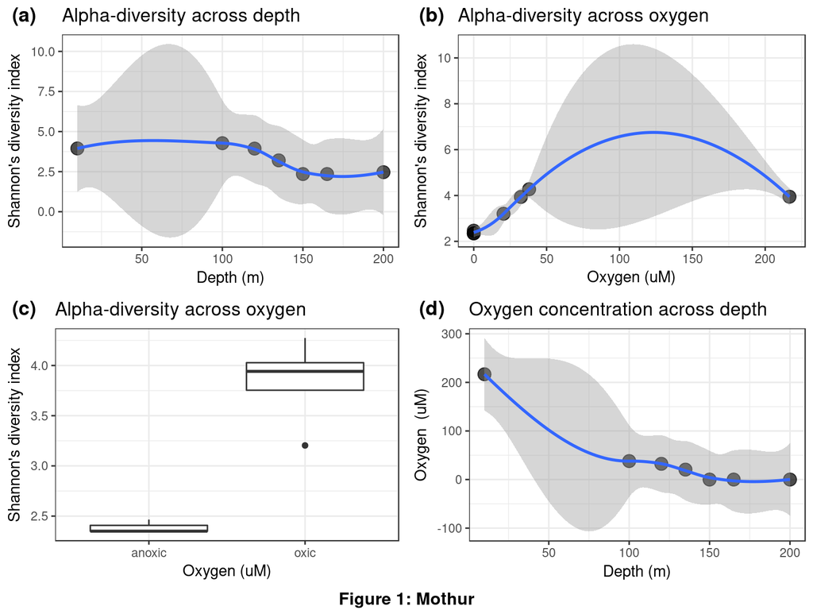

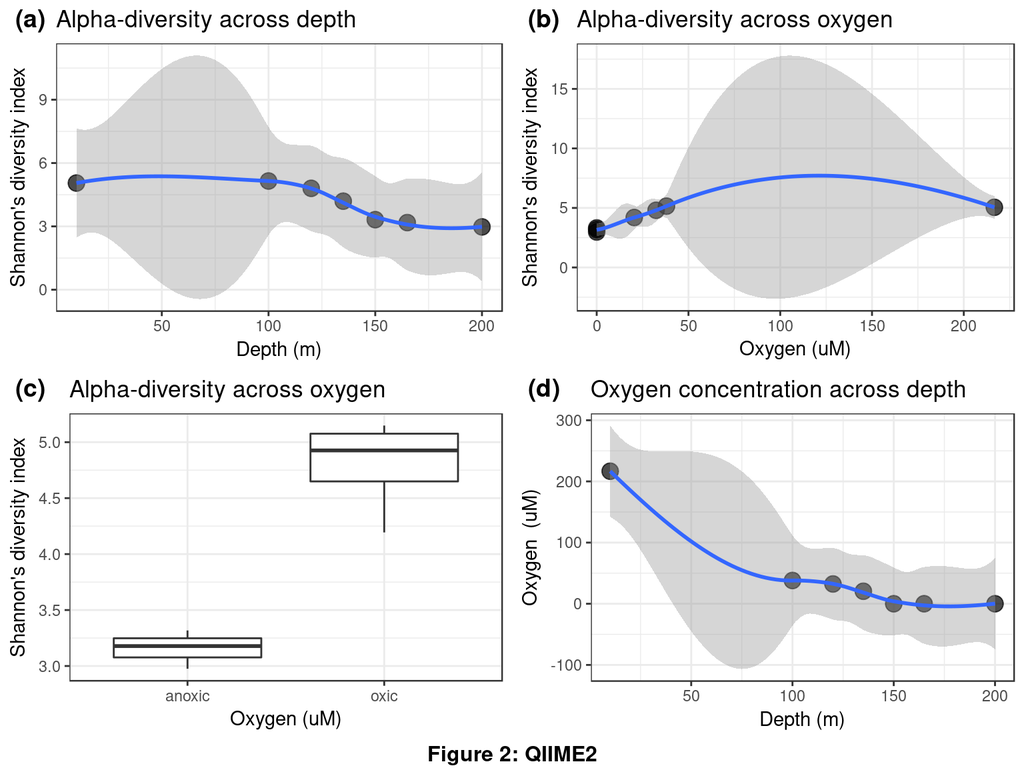

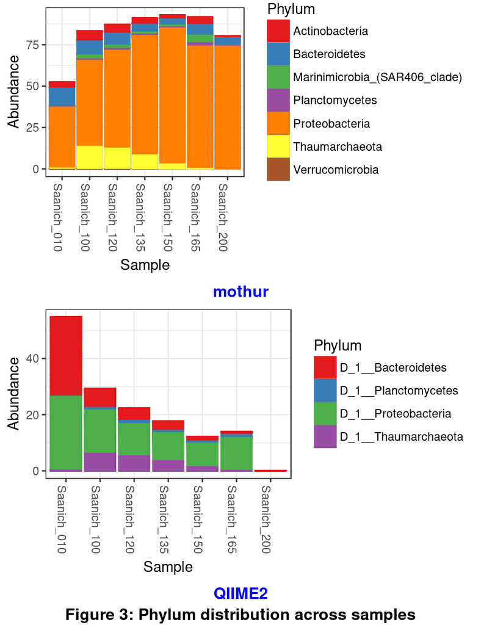

## Analysis of abundance information of Planctomyces along with depth and/or oxygen concentration

Phylums from Mothur vs Phylums from QIIME2

| Phylums from Mothur | Phylums from QIIME2 |
| --- | --- |
| Proteobacteria | D_1__Proteobacteria |
| Bacteroidetes | D_1__Bacteroidetes |
| Thaumarchaeota | D_1__Planctomycetes |
| Actinobacteria | D_1__Thaumarchaeota |
| Marinimicrobia_(SAR406_clade) |  |
| Planctomycetes |  |
| Verrucomicrobia |  |

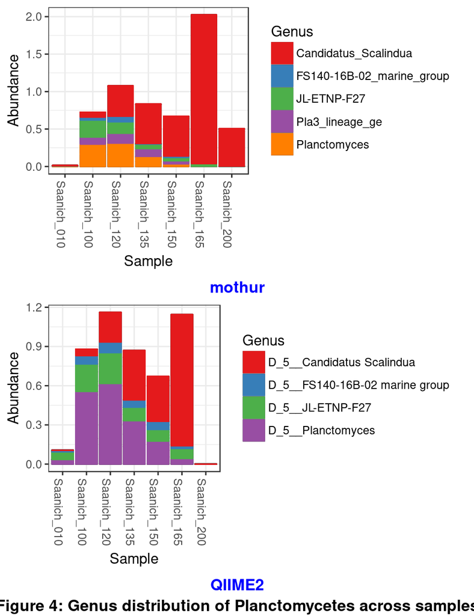

The well known general linear model is employed to recover relationships that might be exhibited between explanatory and target variables. We decompose our hypothesize in a series of experimental tests: i)- first, we investigate the correlation of Planctomyces abundance as a function of depth; and ii)- then, we cross-examine the Planctomyces abundance as a function of oxygen concentration.

Table 2. shows the results of our test analysis. From the statistical perspective, it can be inferred that there might be no relations with either the depth or the oxyzen. This is becasue the coefficients of depth and oxygen and their p-values were found to be $(-0.0003609,$ p-value $= 0.7385598)$ and $(-0.0002544,$ p-value$=0.7616253)$, respectively, which are not statistically significant at $5\%$ (an arbitrary cutoff). Hence, we might reason that there is a little statistical evidence to support our belief that Planctomyces indeed varies across depth and oxygen.

Such contradictory conclusion suggests to accept the null hyptothesis that states no intersting patterns exist for Planctomyces. However, the fitting problem associated with the general linear model underestimate the existence of any kind of interesting relationships. Indeed, when we manually inspected the samples, we found that samples from depth $10, 150, 165$ and $200$ do not or are less planctomyces abundant than at $100, 120$, and $135$ depths, which imply that Planctomyces is quite differentially abundant in Saanich Inlet dataset. Perhaps, using more complex models might provide a better predictive analysis; but for now on, we stick with the statistical outputs.

Correlation data of OTUs within Planctomyces genus across depth and oxyzen concentration from mothur and QIIME2

| Covariates | Estimate | Std. Error | t-value | Pr(>\|t\|) |
| --- | --- | --- | --- | --- |
| Depth (mothur) | -0.0003609 | 0.0010227 | -0.3528908 | 0.7385598 |
| O2_uM (mothur) | -0.0002544 | 0.0007941 | -0.3203956 | 0.7616253 |
| Depth (QIIME2) | -0.0005878 | 0.0018774 | -0.3130933 | 0.7668485 |
| O2_uM (QIIME2) | -0.0005997 | 0.0014441 | -0.4152436 | 0.6951812 |

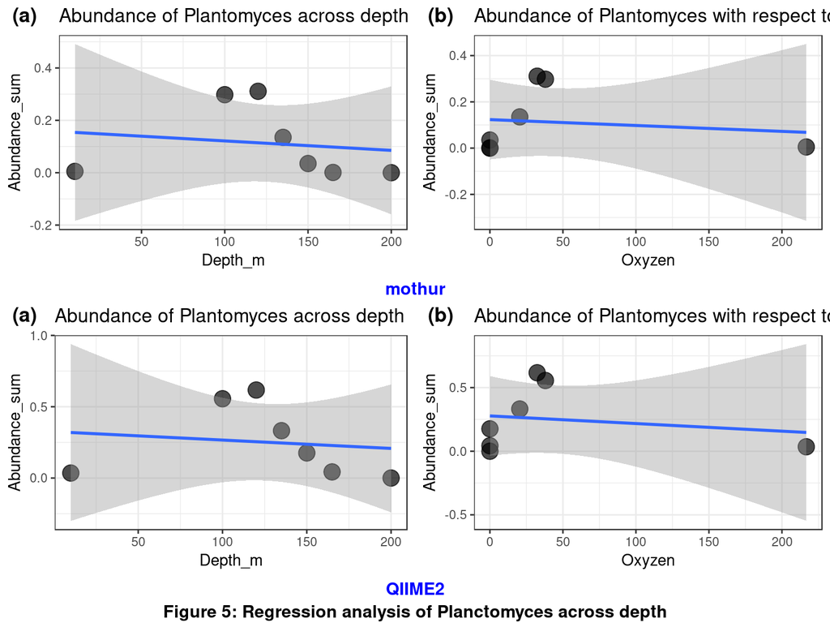

## Estimate richness (number of OTUs/ASVs) for Planctomyces

OTUs from Mothur vs ASVs from QIIME2

| OTUs from Mothur | ASVs from QIIME2 |
| --- | --- |
| Otu0125 | Asv232 |
| Otu0144 | Asv799 |
| Otu0401 | Asv1021 |
| Otu0592 | Asv1124 |

## Interpretation of abundance information of OTUs/ASVs of Planctomyces along with depth and/or oxygen concentration

Correlation data of OTUs within Planctomyces genus across depth

| Covariates | Estimate | Std. Error | t-value | Pr(>\|t\|) |
| --- | --- | --- | --- | --- |
| Otu0125 (mothur) | -0.0002045 | 0.0005479 | -0.3731784 | 0.7243139 |
| Otu0144 (mothur) | -0.0001533 | 0.0004035 | -0.3798581 | 0.7196506 |
| Otu0401 (mothur) | -0.0000009 | 0.0000807 | -0.0113619 | 0.9913741 |
| Otu0592 (mothur) | -0.0000023 | 0.0000274 | -0.0836392 | 0.9365887 |
| Asv232 (QIIME2) | -0.0001665 | 0.0006541 | -0.2545201 | 0.8092302 |
| Asv799 (QIIME2) | -0.0000953 | 0.0005682 | -0.1676505 | 0.8734282 |
| Asv1021 (QIIME2) | 0.0000544 | 0.0001222 | 0.4454921 | 0.6745908 |
| Asv1124 (QIIME2) | -0.0003805 | 0.0005859 | -0.6493922 | 0.5447317 |

Correlation data of OTUs within Planctomyces genus across oxygen concentration

| Covariates | Estimate | Std. Error | t-value | Pr(>\|t\|) |
| --- | --- | --- | --- | --- |
| Otu0125 (mothur) | -0.0001290 | 0.0004265 | -0.3025609 | 0.7744070 |
| Otu0144 (mothur) | -0.0000962 | 0.0003142 | -0.3062077 | 0.7717866 |
| Otu0401 (mothur) | -0.0000196 | 0.0000619 | -0.3172313 | 0.7638869 |
| Otu0592 (mothur) | -0.0000096 | 0.0000208 | -0.4601604 | 0.6647195 |
| Asv232 (QIIME2) | -0.0002374 | 0.0004989 | -0.4759372 | 0.6541875 |
| Asv799 (QIIME2) | -0.0002374 | 0.0004285 | -0.5541303 | 0.6033590 |
| Asv1021 (QIIME2) | -0.0001100 | 0.0000831 | -1.3250528 | 0.2424753 |
| Asv1124 (QIIME2) | -0.0000147 | 0.0004727 | -0.0311450 | 0.9763589 |

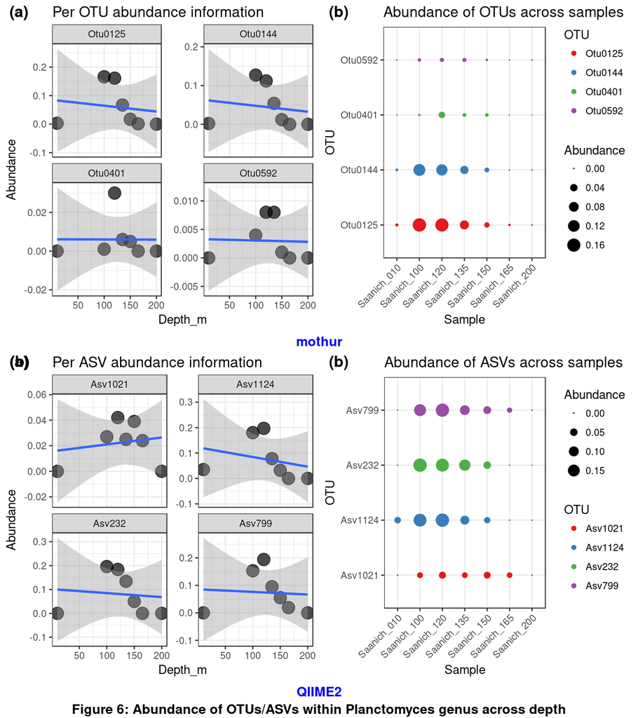

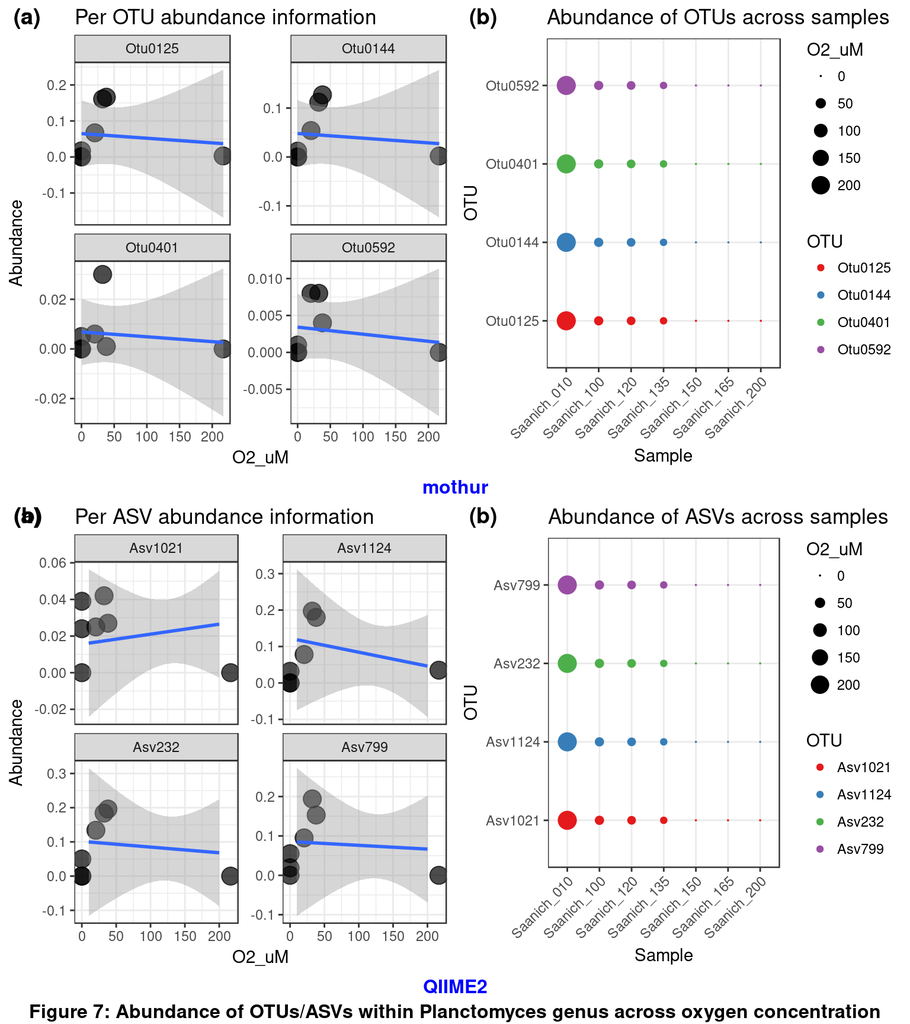

# References

Breitburg, Denise, Lisa A Levin, Andreas Oschlies, Marilaure Grégoire, Francisco P Chavez, Daniel J Conley, Véronique Garçon, et al. 2018. “Declining Oxygen in the Global Ocean and Coastal Waters.” *Science* 359 (6371). American Association for the Advancement of Science: eaam7240.

Callahan, Benjamin J, Paul J McMurdie, and Susan P Holmes. 2017. “Exact Sequence Variants Should Replace Operational Taxonomic Units in Marker-Gene Data Analysis.” *The ISME Journal* 11 (12). Nature Publishing Group: 2639.

Chen, Wei, Clarence K Zhang, Yongmei Cheng, Shaowu Zhang, and Hongyu Zhao. 2013. “A Comparison of Methods for Clustering 16s rRNA Sequences into Otus.” *PloS One* 8 (8). Public Library of Science: e70837.

Finotello, Francesca, Eleonora Mastrorilli, and Barbara Di Camillo. 2016. “Measuring the Diversity of the Human Microbiota with Targeted Next-Generation Sequencing.” *Briefings in Bioinformatics*. Oxford University Press, bbw119.

Hallam, Steven J, Mónica Torres-Beltrán, and Alyse K Hawley. 2017. “Monitoring Microbial Responses to Ocean Deoxygenation in a Model Oxygen Minimum Zone.” *Scientific Data* 4. Nature Publishing Group.

Hastie, Trevor, Robert Tibshirani, and Jerome Friedman. 2009. *The Elements of Statistical Learning: Data Mining, Inference and Prediction*. 2nd ed. Springer.

Hawley, Alyse K, Mónica Torres-Beltrán, Elena Zaikova, David A Walsh, Andreas Mueller, Melanie Scofield, Sam Kheirandish, et al. 2017. “A Compendium of Multi-Omic Sequence Information from the Saanich Inlet Water Column.” *Scientific Data* 4. Nature Publishing Group: 170160.

Schloss, Patrick D, Sarah L Westcott, Thomas Ryabin, Justine R Hall, Martin Hartmann, Emily B Hollister, Ryan A Lesniewski, et al. 2009. “Introducing Mothur: Open-Source, Platform-Independent, Community-Supported Software for Describing and Comparing Microbial Communities.” *Applied and Environmental Microbiology* 75 (23). Am Soc Microbiol: 7537–41.

Torres-Beltrán, Mónica, Alyse K Hawley, David Capelle, Elena Zaikova, David A Walsh, Andreas Mueller, Melanie Scofield, et al. 2017. “A Compendium of Geochemical Information from the Saanich Inlet Water Column.” *Scientific Data* 4. Nature Publishing Group: 170159.